# A6_Tasks

## A6_T1 Read text file

### Datasets

- A6_T1_D1.txt
- A6_T1_D2.txt
- A6_T1_D3.txt

Create a program that can read a text file and then print the file content. User must be able to specify the file name. Decorate the beginning and the end of the file with a decorative line.

**Decorative lines**

- `#### START "{filename}" ####`
- `#### END "{filename}" ####`

**Example program runs**

```
Program starting.
This program can read a file.
Insert filename: A6_T1_D1.txt
#### START "A6_T1_D1.txt" ####
Hello
World

#### END "A6_T1_D1.txt" ####
Program ending.
```

```
Program starting.
This program can read a file.
Insert filename: A6_T1_D2.txt
#### START "A6_T1_D2.txt" ####
Liam
Olivia
Ethan
Sophia
Noah
Isabella
Aiden
Mia
Lucas
Ava

#### END "A6_T1_D2.txt" ####
Program ending.
```

```
Program starting.
This program can read a file.
Insert filename: A6_T1_D3.txt
#### START "A6_T1_D3.txt" ####
Lorem ipsum dolor sit amet, consectetur adipiscing elit. Phasellus nec libero vitae metus vehicula lacinia. Fusce efficitur purus ac urna tempus varius. Sed consequat, purus nec varius bibendum, est justo viverra libero, a semper odio eros vel turpis. Suspendisse potenti. In hac habitasse platea dictumst. Etiam ut ante non mi tincidunt tincidunt ac nec purus. Proin ut justo at arcu dignissim consequat. Integer posuere volutpat urna, vel dignissim lectus feugiat nec. Pellentesque habitant morbi tristique senectus et netus et malesuada fames ac turpis egestas. Nulla facilisi. Vivamus tincidunt aliquam ante, at bibendum justo eleifend a. Ut vitae bibendum urna, a euismod libero. Curabitur malesuada efficitur neque, in volutpat odio maximus eu.

#### END "A6_T1_D3.txt" ####
Program ending.
```

## A6_T2 Write text file

Create a program that can write a text file. Prompt the user to insert first name and last name. Then prompt the file name for the write operation. Finally write a text file with first name on the first row and last name on the second row. Ensure that the text file ends in a empty row. Finally exit the program cleanly.

**Example program runs**

```
Program starting.
Insert first name: Guido
Insert last name: Rossum
Insert filename: A6_T2_F1.txt
Program ending.
```

```
Program starting.
Insert first name: David
Insert last name: Goodger
Insert filename: A6_T2_F2.txt
Program ending.
```

```
Program starting.
Insert first name: Tim
Insert last name: Peters
Insert filename: A6_T2_F3.txt
Program ending.
```

**Example written file:**

```
Guido
Rossum
```

```
David
Goodger
```

```
Tim
Peters
```

## A6_T3 Copy text file

### Datasets

- A6_T3_D1.txt
- A6_T3_D2.txt
- A6_T3_D3.txt

Create a program that copies a text file by reading from a source file and writing the content to a destination file. Allow the user to specify the source and destination file names.

**Example program runs**

```
Program starting.
This program can copy a file.
Insert source filename: A6_T3_D1.txt
Insert destination filename: A6_T3_F1.txt
Reading file 'A6_T3_D1.txt' content.
File content ready in memory.
Writing content into file 'A6_T3_F1.txt'.
Copying operation complete.
Program ending.
```

```
Program starting.
This program can copy a file.
Insert source filename: A6_T3_D2.txt
Insert destination filename: A6_T3_F2.txt
Reading file 'A6_T3_D2.txt' content.
File content ready in memory.
Writing content into file 'A6_T3_F2.txt'.
Copying operation complete.
Program ending.
```

```
Program starting.
This program can copy a file.
Insert source filename: A6_T3_D3.txt
Insert destination filename: A6_T3_F3.txt
Reading file 'A6_T3_D3.txt' content.
File content ready in memory.
Writing content into file 'A6_T3_F3.txt'.
Copying operation complete.
Program ending.
```

## A6_T4 String analytics

### Datasets

- A6_T4_D1.txt
- A6_T4_D2.txt
- A6_T4_D3.txt

Create a Python program which is able to analyse names listed in a text file (See dataset files):

Analyse and specify following aspects from the file:

1. The amount of names
2. Shortest name
3. Longest name
4. Average name length.

Let the user specify the filename for the analysis. Program reads the file and prints the results from the analysis. Values must be presented like shown in the example program runs. Average name length must be presented in 2 decimal precision. Use [Format Specification Mini-Language](https://docs.python.org/3/library/string.html#formatspec) to achieving the required precision for the data presentation.

Note! Given text files may contain empty rows and the program must be able to skip them if present.

**Other tips:**

- Read text file line-by-line.
- Pay attention to the reading process (newline characters).
- Names can be stored into a single string variable.
  - Consider separating names with a semicolon `;`
    - `John;Doe;Jane`
- Report can be stored into one string variable.
- [Format Specification Mini-Language](https://docs.python.org/3/library/string.html#formatspec).
  - E.g., `"Value in 2 decimal precision {:.2f}".format(3.555)`

**Example program runs**

```
Program starting.
This program analyses a list of names from a file.
Insert filename to read: A6_T4_D1.txt
Reading names from "A6_T4_D1.txt".
Analysing names...
Analysis complete!
#### REPORT BEGIN ####
Name count - 2
Shortest name - 3 chars
Longest name - 4 chars
Average name - 3.50 chars
#### REPORT END ####
Program ending.
```

```
Program starting.
This program analyses a list of names from a file.
Insert filename to read: A6_T4_D2.txt
Reading names from "A6_T4_D2.txt".
Analysing names...
Analysis complete!
#### REPORT BEGIN ####
Name count - 9
Shortest name - 7 chars
Longest name - 11 chars
Average name - 9.33 chars
#### REPORT END ####
Program ending.
```

```
Program starting.
This program analyses a list of names from a file.
Insert filename to read: A6_T4_D3.txt
Reading names from "A6_T4_D3.txt".
Analysing names...
Analysis complete!
#### REPORT BEGIN ####
Name count - 40
Shortest name - 6 chars
Longest name - 11 chars
Average name - 7.95 chars
#### REPORT END ####
Program ending.
```

## A6_T5 Number analytics (TEST TASK)

### Datasets

- A6_T5_D1.txt
- A6_T5_D2.txt
- A6_T5_D3.txt

Create a program which can analyse numbers in a text file.

Required values in analysis:

1. Total - integer - Sum of numbers
2. Count - integer - Rows that contain values
3. Greatest - integer - The greatest number of them all
4. Average - decimal - The numbers average

Think about the processes or “steps” of the analytics first. A prosess which can be described with a name should be wrapped into a function. This function then should only do the task, which belongs to it based on the name. For example if the function name is “readValues”, then the function should read the values from a file. If the function name is “`analyseNumbers`”, then it should not read a textfile.

This can be difficult at first with the current know-how, because return statement can only return one value and we have not looked into the datastructures yet. But if you want, you can wrap the values into a string variable using separator in-between the values. This way string can contain multiple values and can be returned as a single value from a function.

**Pseudo-example below:**

```python
SEPARATOR = ";"

def readValues() -> str:
  # read operations...
  Values: str = ""
  Values += str(13) + SEPARATOR
  Values += str(45) + SEPARATOR
  Values += str(20)
  return Values
```

This task will not evaluate how well you have structured your code or separated the processes into their own functionalities. But definitely this is a good place to start to consider how robust code are you actually building.

Present average result in 2 digit precision. Utilize the [Format Specification Mini-Language](https://docs.python.org/3/library/string.html#formatspec).

Syntax for 2 digit precision: `'{:.2f}'`

**Dataset details:**

- These datasets contain only positive integer numbers.
- No empty lines. [POSIX Line definition](https://pubs.opengroup.org/onlinepubs/9699919799/basedefs/V1_chap03.html#tag_03_206)

The results are displayed in CSV format in the example program runs. The first row contains headers, followed by a single data row. Both the column headers and the data values are separated by a semicolon (`;`). The format is similar to how data is structured in Excel.

| Count | Sum | Greatest | Average |
| --- | --- | --- | --- |
| 2 | 53 | 43 | 26.50 |

**Example program runs**

```
Program starting.
Insert filename: A6_T5_D1.txt
#### Number analysis - START ####
File "A6_T5_D1.txt" results:
Count;Sum;Greatest;Average
2;53;43;26.50

#### Number analysis - END ####
Program ending.
```

```
Program starting.
Insert filename: A6_T5_D2.txt
#### Number analysis - START ####
File "A6_T5_D2.txt" results:
Count;Sum;Greatest;Average
10;508;91;50.80

#### Number analysis - END ####
Program ending.
```

```
Program starting.
Insert filename: A6_T5_D3.txt
#### Number analysis - START ####
File "A6_T5_D3.txt" results:
Count;Sum;Greatest;Average
100;5608;98;56.08

#### Number analysis - END ####
Program ending.
```

## A6_T6 Cipher messages (TEST TASK)

In this exercise, get familiar with the [Caesar cipher](https://en.wikipedia.org/wiki/Caesar_cipher) and specificly on the ROT13 implementation.

Caesar Cipher explained (3 minutes): youtu.be/sMOZf4GN3oc

[figure not shown]

Click to play in YouTube

ROT13 Converter

Plain text

Ciphered text

Create a Python program which collects plain text rows from user till the user inserts an empty row. Cipher all rows and then ask user to choose between showing the ciphered text or saving it.

| A | B | C | D | E | F | G | H | I | J | K | L | M | N | O | P | Q | R | S | T | U | V | W | X | Y | Z |
| --- | --- | --- | --- | --- | --- | --- | --- | --- | --- | --- | --- | --- | --- | --- | --- | --- | --- | --- | --- | --- | --- | --- | --- | --- | --- |
| N | O | P | Q | R | S | T | U | V | W | X | Y | Z | A | B | C | D | E | F | G | H | I | J | K | L | M |

Program must be able to cipher following lowercase and uppercase alphabets. Other characters remains same during ciphering operation.

```python
# English alphabets (2 x 26)
LOWER_ALPHABETS = "abcdefghijklmnopqrstuvwxyz"
UPPER_ALPHABETS = "ABCDEFGHIJKLMNOPQRSTUVWXYZ"
```

Example program runs:

```
Program starting.

Collecting plain text rows for ciphering.
Insert row(empty stops): Hello
Insert row(empty stops): World
Insert row(empty stops):

#### Ciphered text ####
Uryyb
Jbeyq

#### Ciphered text ####
Insert filename to save: A6_T6_F1.txt
Ciphered text saved!
Program ending.
```

```
Program starting.

Collecting plain text rows for ciphering.
Insert row(empty stops): Veni
Insert row(empty stops): vidi
Insert row(empty stops): vici
Insert row(empty stops):

#### Ciphered text ####
Irav
ivqv
ivpv

#### Ciphered text ####
Insert filename to save: A6_T6_F2.txt
Ciphered text saved!
Program ending.
```

```
Program starting.

Collecting plain text rows for ciphering.
Insert row(empty stops): Fortuna audaces iuvat.
Insert row(empty stops): Alea iacta est.
Insert row(empty stops): Gallia est omnis divisa in partes tres.
Insert row(empty stops):

#### Ciphered text ####
Sbeghan nhqnprf vhing.
Nyrn vnpgn rfg.
Tnyyvn rfg bzavf qvivfn va cnegrf gerf.

#### Ciphered text ####
Insert filename to save: A6_T6_F3.txt
Ciphered text saved!
Program ending.
```

```
Program starting.

Collecting plain text rows for ciphering.
Insert row(empty stops): Hello
Insert row(empty stops):

#### Ciphered text ####
Uryyb

#### Ciphered text ####
Insert filename to save:
File name not defined.
Aborting save operation.
Program ending.
```

# A6_T7 Messages from the Four Emperors

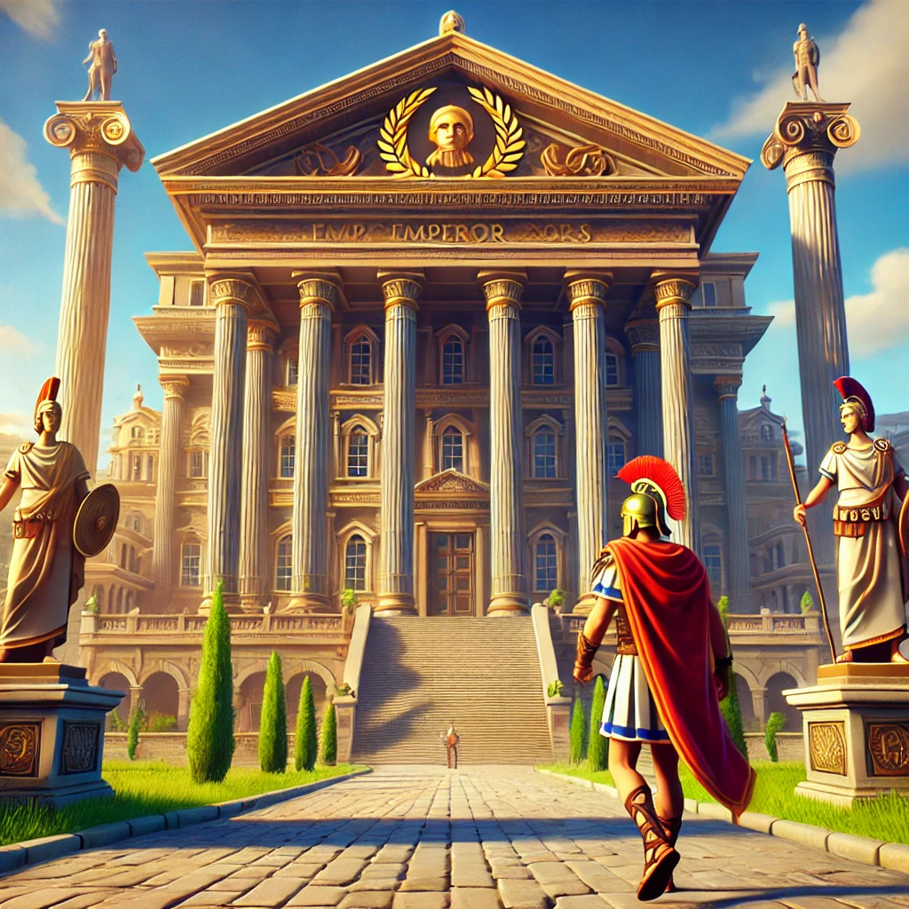

Each of the Four Emperors—Galba, Otho, Vitellius and Vespasian—has left a message in their own palaces. Your task is to travel programmatically to each location and gather all their messages.

You may travel only once per program run. Travel should begin by displaying the current location, followed by the process of traveling to the next location. The first location is the “start” or “Home” location on the map below.

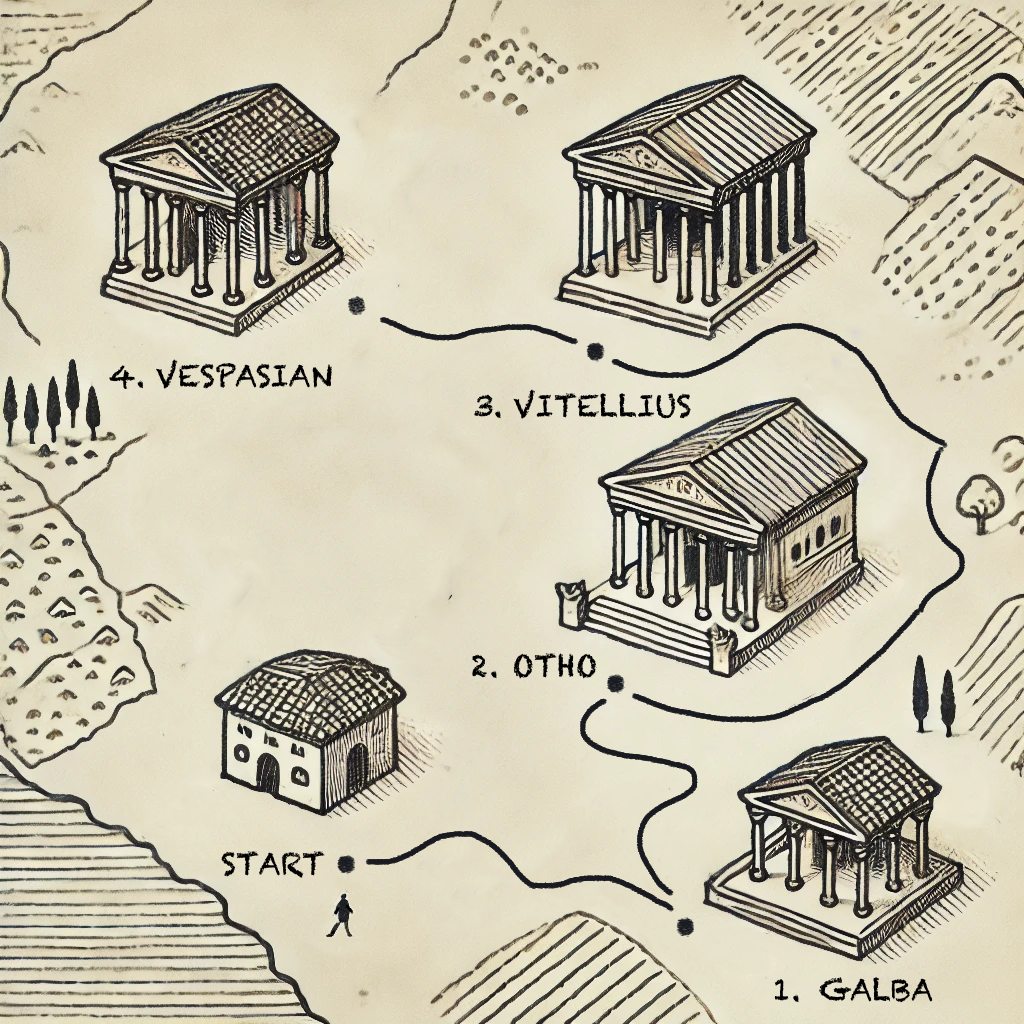

**Place names listed:**

0. home
1. Galba's palace
2. Otho's palace
3. Vitellius' palace
4. Vespasian's palace

Create a file “`player_progress.txt`” and initialize it with the following details.

```
current_location;next_location;passphrase
0;1;qvfpvcyvar
```

**Player progress file explained:**

1. First row is the header row with the column names.
2. Data row 1
   1. Current location id `0` refers to the starting point (Home).
   2. Next location id `1` refers to the next objective (Galba's palace).
   3. Passphrase ciphered (ROT13)
3. Next data row
   1. Should be added after progress is made on it’s own new line in the same file.

Once you have traveled to the destination, walk into the palace and shout the passphrase(print the plain version) to the guard as you enter. After entering, locate the message (open file `"{NextLocationId}_{PassPhrase}.gkg"`) and read the content.

The “.gkg” file extension in this context means that the text file content is in ciphered form. It can be deciphered back to plain text using the Ceasar Cipher (ROT13).

Read the first line as ciphered text and append it to the `player_progress.txt`. After the first line, save the plain version of the message into `"{NextLocationId}-{PlainPassPhrase}.txt"`.

**Examples of message formats:**

- file1: Ciphered message `"{NextLocationId}_{PassPhrase}.gkg"`
- file2: Plain version to save `"{NextLocationId}-{PlainPassPhrase}.txt"`

```
0;1;qvfpvcyvar
Cneg 0 - Lrne bs gur Sbhe Rzcrebef:

Va NQ 68, nsgre Areb'f qrngu, Ebzr cyhatrq vagb punbf.
Jvgu ab pyrne urve, gur rzcver fnj encvq cbjre fgehttyrf.
Tnyon gbbx gur guebar svefg, sbyybjrq ol Bgub, Ivgryyvhf, naq svanyyl Irfcnfvna,
rnpu onggyvat sbe pbageby va jung orpnzr gur Lrne bs gur Sbhe Rzcrebef.
```

```
Part 0 - Year of the Four Emperors:

In AD 68, after Nero's death, Rome plunged into chaos.
With no clear heir, the empire saw rapid power struggles.
Galba took the throne first, followed by Otho, Vitellius, and finally Vespasian,
each battling for control in what became the Year of the Four Emperors.
```

After the progress and the Emperor’s message have been saved, the program closes with the final phrases. The next time the program runs, it should be able to read the previous progress from `player_progress.txt` and continue the next turn.

**Example program runs:**

```
Travel starting.
Currently at home.
Travelling to Galba's palace...
...Arriving to the Galba's palace.
Passing the guard at the entrance.
"Discipline!"
Looking for the message in the palace...
Ah, there it is! Seems cryptic.
[Game] Progress autosaved!
Deciphering Emperor's message...
Looks like I've got now the plain version copy of the Emperor's message.
Time to leave...
Travel ending.
```

```
Travel starting.
Currently at Galba's palace.
Travelling to Otho's palace...
...Arriving to the Otho's palace.
Passing the guard at the entrance.
"PASS_PHRASE_HERE!"
Looking for the message in the palace...
Ah, there it is! Seems cryptic.
[Game] Progress autosaved!
Deciphering Emperor's message...
Looks like I've got now the plain version copy of the Emperor's message.
Time to leave...
Travel ending.
```

```
Travel starting.
Currently at Otho's palace.
Travelling to Vitellius' palace...
...Arriving to the Vitellius' palace.
Passing the guard at the entrance.
"PASS_PHRASE_HERE!"
Looking for the message in the palace...
Ah, there it is! Seems cryptic.
[Game] Progress autosaved!
Deciphering Emperor's message...
Looks like I've got now the plain version copy of the Emperor's message.
Time to leave...
Travel ending.
```

```
Travel starting.
Currently at Vitellius' palace.
Travelling to Vespasian's palace...
...Arriving to the Vespasian's palace.
Passing the guard at the entrance.
"PASS_PHRASE_HERE!"
Looking for the message in the palace...
Ah, there it is! Seems cryptic.
[Game] Progress autosaved!
Deciphering Emperor's message...
Looks like I've got now the plain version copy of the Emperor's message.
Time to leave...
Travel ending.
```